# HELPmiss (Data Verbs) Activity

## Task 2: Basic Summaries

*Produce one or more R expressions involving `summarize()` and `HELPmiss` to address each of the following prompts.*

1. number of people (cases) in `HELPmiss` study

```r
library(dplyr)

number_of_cases <- HELPmiss %>%
  summarize(number_of_people = n())

number_of_cases
```

| number_of_people |
| --- |
| 470 |

```r
NA
```

2. total number of times in the past 6 months entered a detox program (measured at baseline) for all the people in `HELPmiss`.

```r
library(dplyr)
# Check column names in HELPmiss dataset
column_names <- names(HELPmiss)
column_names
```

```
 [1] "age"              "anysub"           "cesd"             "d1"               "daysanysub"
 [6] "dayslink"         "drugrisk"         "e2b"              "female"           "sex"
[11] "g1b"              "homeless"         "i1"               "i2"               "id"
[16] "indtot"           "link"             "mcs"              "pcs"              "pss_fr"
[21] "racegrp"          "satreat"          "sexrisk"          "substance"        "treat"
[26] "avg_drinks"       "max_drinks"       "hospitalizations"
```

```r
?HELPmiss
total_detox_entries <- HELPmiss %>%
  summarize(total_entries = sum(e2b))

total_detox_entries
```

| total_entries |
| --- |
| NA |

```r
NA
NA
```

3. mean time (in days) to first use of any substance post-detox for all the people in `HELPmiss`

```r
library(dplyr)

mean_time_post_detox <- HELPmiss %>%
  summarize(mean_time = mean(daysanysub))

mean_time_post_detox
```

| mean_time |
| --- |
| NA |

```r
NA
NA
```

## Task 3: Group Summaries

*Repeat task 2 above, but add code chunks to calculate result group-by-group according to each prompt (i.e. each promt should have three statements for each of the three prompts in task 2). Be sure to show all R code and write a sentence or two about what you observe in the results. Remember, you can add multiple statistics inside `summary`.*

- males versus females
- homeless or not
- substance
- break down the homeless versus housed further, by sex
- homeless versus housed broken down by substance

### males versus females

```r
library(dplyr)

detox_entries_by_gender <- HELPmiss %>%
  group_by(sex) %>%
  summarize(total_entries = sum(e2b))

detox_entries_by_gender
```

| sex | total_entries |
| --- | --- |
| male | NA |
| female | NA |

```r
NA
NA
```

### homeless or not

```r
library(dplyr)

detox_entries_by_homeless <- HELPmiss %>%
  group_by(homeless) %>%
  summarize(total_entries = sum(e2b))

detox_entries_by_homeless
```

| homeless | total_entries |
| --- | --- |
| housed | NA |
| homeless | NA |

```r
NA
NA
```

### substance

```r
library(dplyr)

detox_entries_by_substance <- HELPmiss %>%
  group_by(substance) %>%
  summarize(total_entries = sum(e2b))

detox_entries_by_substance
```

| substance | total_entries |
| --- | --- |
| alcohol | NA |
| cocaine | NA |
| heroin | NA |
| missing | 1 |

```r
NA
NA
```

### homeless versus housed broken down by sex

```r
library(dplyr)

detox_entries_by_homeless_sex <- HELPmiss %>%
  group_by(homeless, sex) %>%
  summarize(total_entries = sum(e2b))
detox_entries_by_homeless_sex
```

| homeless | sex | total_entries |
| --- | --- | --- |
| housed | male | NA |
| housed | female | NA |
| homeless | male | NA |
| homeless | female | NA |

```r
NA
NA
```

### homeless versus housed broken down by substance

```r
library(dplyr)

detox_entries_by_homeless_substance <- HELPmiss %>%
  group_by(homeless, substance) %>%
  summarize(total_entries = sum(e2b))
detox_entries_by_homeless_substance
```

| homeless | substance | total_entries |
| --- | --- | --- |
| housed | alcohol | NA |
| housed | cocaine | NA |
| housed | heroin | NA |
| homeless | alcohol | NA |
| homeless | cocaine | NA |
| homeless | heroin | NA |
| homeless | missing | 1 |

```r
NA
NA
```

## Task 4: Data Visualization & Observations

*Include one or more interesting plots from this data set involving at least 3 variables per plot. Write a few sentences to explain the story that your plot tells about these data. You can expand on the relationships that you studied in Task 2, or you can explore a different group of variables in `HELPmiss` that show something interesting. Remember to use the interactive commands in the console, generate the R commands that will reproduce your plot, and then paste the R commands into an R chunk in the RMarkdown file.*

*Remember, you can use* `esquisser` *or* `mplot` *in your console. But only include the ggplot code in this Rmd document.*

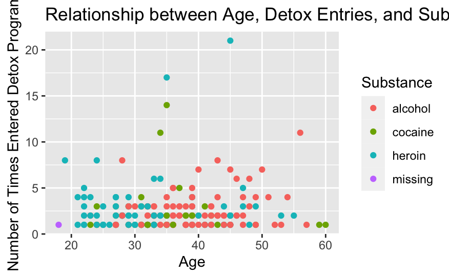

```r
library(ggplot2)

ggplot(HELPmiss, aes(x = age, y = e2b, color = substance)) +
  geom_point() +
  labs(x = "Age", y = "Number of Times Entered Detox Program", color = "Substance") +
  ggtitle("Relationship between Age, Detox Entries, and Substance Use")
```